# DESeq2-MultiBatch: Batch Correction for Multi-Factorial RNA-seq Experiments

Julien Roy

2026-01-15

```r
library(knitr)
library(DESeq2)
library(tidyverse)
library(apeglm)
library(RColorBrewer)
library(limma)
library(pheatmap)
library(gtools)
library(plotly)
library(sva)
library(patchwork)
library(gridExtra)
```

# Abstract

This document explores the experimental design as shown in “DESeq2-MultiBatch: Batch Correction for Multi-Factorial RNA-seq Experiments”.

The first part will explain how the batch factor affects results and show in detail how to take its effect into account. To obtain corrected counts for downstream analysis or visualizations, the DESeq2-MultiBatch will be applied and compared with limma’s RemoveBatchEffects and ComBat_Seq.

The second part will provide recommendations and practical strategies for performing DESeq2 analysis with complex experimental designs. It includes specific guidance on constructing design matrices, addressing imbalanced datasets, defining appropriate contrasts, and conducting multi-factorial analyses with illustrative examples.

For more information about DESeq2 and the standard RNA-Seq analysis steps, refer to:

- [Analyzing RNA-seq data with DESeq2](https://bioconductor.org/packages/release/bioc/vignettes/DESeq2/inst/doc/DESeq2.html) (Love & al., 2025)
- [RNA-seq workflow: gene-level exploratory analysis and differential expression](https://bioconductor.org/packages/release/workflows/vignettes/rnaseqGene/inst/doc/rnaseqGene.html) (Love & al., 2019)

# Context

Samples in this fictional study are presented as coming from two separate experimental runs carried out under distinct growth contexts (e.g., different greenhouse compartments or experiments performed at different times). Although the biological design was identical in both runs, plants did not experience fully comparable environmental conditions (e.g., microclimate, handling routines, stress exposure, or day-to-day management).

As a result, expression profiles may differ between runs due to environmental and procedural differences rather than biology alone. Throughout this document, these experimental runs are referred to as batches. Because plant responses to growth conditions can depend on biological traits such as physiological stage, cultivar or sex, batch effects may interact with these factors rather than act as simple technical offsets (usually from sampling techniques, processing, etc.).

## Experimental design

This tutorial uses a simulated RNA-seq dataset (1 000 genes, 48 samples) to illustrate the batch-correction workflow. The precise way the data were simulated, including how closely they mimic real RNA-seq counts, is not important for understanding the method.

The study design includes dioecious plants (males and females) generated across **two experimental batches**. Importantly, both male and female control plants were profiled in each batch at day 0 (baseline, seedlings vegetative stage). Because these day-0 samples are biologically matched controls, they provide a clean baseline to quantify batch-related expression offsets, including offsets that may differ between sexes.

In the first part of this document, we therefore restrict the analysis to day 0 control samples and focus on how batch effects appear in males and females. Details about later time points, photoperiod shift, and sex-specific treatments are introduced in Part 2 for downstream analyses.

## Loading data files

```r
# load metadata
colData <- read.csv(file = "coldata.csv")
colData[,2:6] <- lapply(colData[,2:6], as.factor)

# load counts
counts <- read.csv(file = "counts.csv", check.names = FALSE, row.names = 1)

# assign SampleID as column names of counts
colnames(counts) <- colData$SampleID

# keep only Day 0 samples for first part
colData0 <- colData %>%
  dplyr::filter(Day == 0)

counts0 <- counts[, colData0$SampleID]
```

Samples are rows in the ColData, with factors as columns. In the count file, rows are genes with samples as columns.

|  | SampleID | Genotype | Sex | Day | Batch | Treatment |
| --- | --- | --- | --- | --- | --- | --- |
| 1 | Sample1 | c1 | xx | 0 | a | ctrl |
| 2 | Sample2 | c1 | xx | 0 | a | ctrl |
| 3 | Sample3 | c1 | xx | 0 | a | ctrl |
| 4 | Sample4 | c2 | xx | 0 | a | ctrl |
| 5 | Sample5 | c2 | xx | 0 | a | ctrl |
| 6 | Sample6 | c2 | xx | 0 | a | ctrl |

## Exploratory analysis and visualization

To view the relationship between sample groups a simple *dds* object is first created.

The factors included in the design used for the basic DESeq2 analysis assume no batch effects and does not bother about genotypes (yet).

```r
# design
design_sex0 <- ~ Sex

# construct a DESeqDataSet object
dds_sex0 <- DESeqDataSetFromMatrix(countData = counts0,
                                  colData = colData0,
                                  design = design_sex0)

dds_sex0 <- DESeq(dds_sex0)

resultsNames(dds_sex0)
```

```
## [1] "Intercept"    "Sex_xy_vs_xx"
```

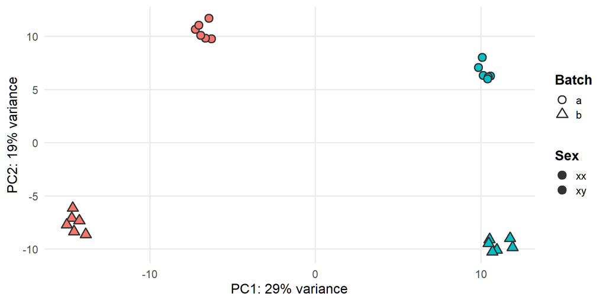

The day-0 PCA shows four very tight clusters that correspond to Sex × Batch. Importantly, XX controls from Batch A and Batch B do not cluster together, and the same is true for XY controls. This indicates a sizable batch effect even among biologically matched controls (genotype is not shown and does not drive the clustering).

As the separation seen in the PCA suggests that batch variation is on a similar scale as the sex effect. A natural next step is to include batch in the DESeq2 design.

But first, this step establishes the baseline sex contrast using the simplest possible model previously created :

```r
# Sex effect: XY vs XX
res_sex <- results(dds_sex0, contrast = c("Sex", "xy", "xx"), independentFiltering = FALSE)
summary(res_sex)
```

```
##
## out of 1000 with nonzero total read count
## adjusted p-value < 0.1
## LFC > 0 (up)       : 241, 24%
## LFC < 0 (down)     : 230, 23%
## outliers [1]       : 0, 0%
## low counts [2]     : 0, 0%
## (mean count < 0)
## [1] see 'cooksCutoff' argument of ?results
## [2] see 'independentFiltering' argument of ?results
```

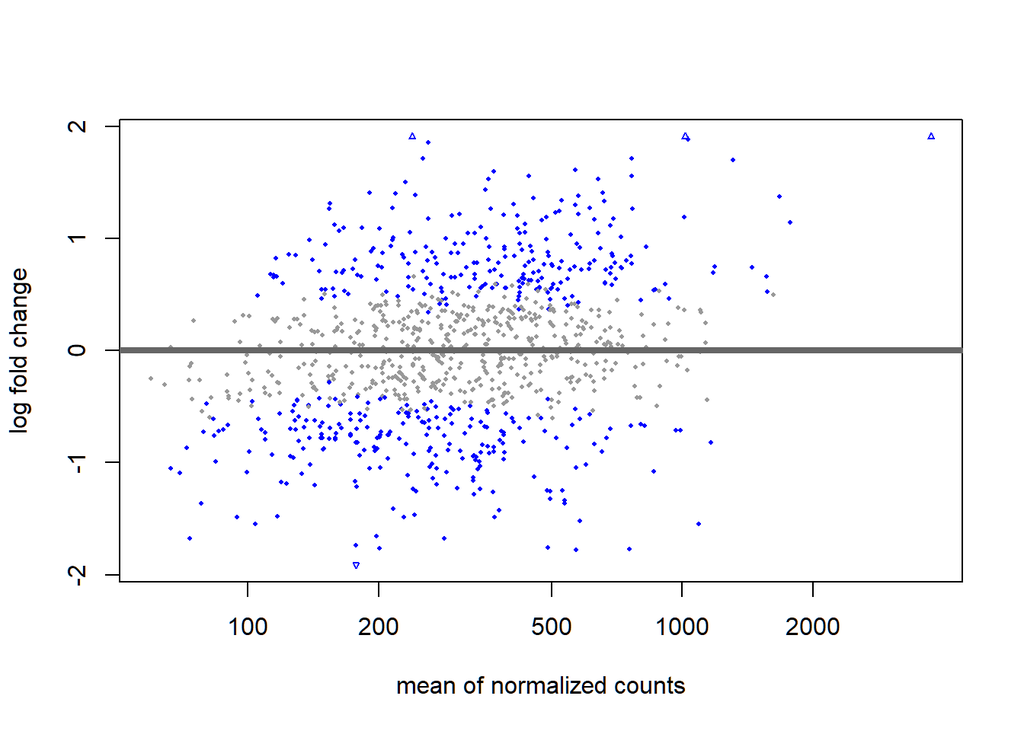

```r
DESeq2::plotMA(res_sex)
```

Here, DESeq2 compares XY vs XX using all day-0 samples, treating them as if they were grown under identical conditions. Batch is ignored, so any systematic differences between batches are implicitly absorbed into the sex effect.

The output shows that nearly half of all genes (≈47%) are called differentially expressed between sexes at padj < 0.1.

This raw contrast therefore provides the reference point: it shows what DESeq2 reports when sex is analyzed without correcting for batch or batch and sex interactions. Subsequent models will be compared against this baseline.

Now, adding a batch factor.

```r
design_sex_batch0 <- ~ Sex + Batch

dds_batch0 <- DESeqDataSetFromMatrix(countData = counts0,
                                  colData = colData0,
                                  design = design_sex_batch0)

dds_batch0 <- DESeq(dds_batch0)

resultsNames(dds_batch0)
```

```
## [1] "Intercept"    "Sex_xy_vs_xx" "Batch_b_vs_a"
```

```r
# Sex effect: XY vs XX
res_sex_batch <- results(dds_batch0, contrast = c("Sex", "xy", "xx"), independentFiltering = FALSE)
summary(res_sex_batch)
```

```
##
## out of 1000 with nonzero total read count
## adjusted p-value < 0.1
## LFC > 0 (up)       : 263, 26%
## LFC < 0 (down)     : 259, 26%
## outliers [1]       : 0, 0%
## low counts [2]     : 0, 0%
## (mean count < 0)
## [1] see 'cooksCutoff' argument of ?results
## [2] see 'independentFiltering' argument of ?results
```

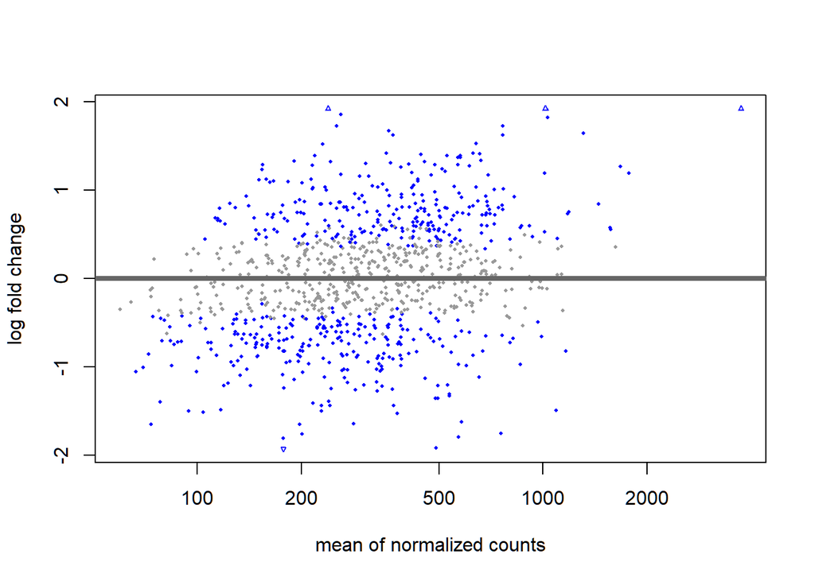

```r
DESeq2::plotMA(res_sex_batch)
```

And finally, adding the interaction term.

```r
design_all0 <- ~ Sex * Batch

dds_all0 <- DESeqDataSetFromMatrix(countData = counts0,
                                  colData = colData0,
                                  design = design_all0)

dds_all0 <- DESeq(dds_all0)

resultsNames(dds_all0)
```

```
## [1] "Intercept"    "Sex_xy_vs_xx" "Batch_b_vs_a" "Sexxy.Batchb"
```

```r
sex_all_a <- results(dds_all0, contrast = c("Sex", "xy", "xx"), independentFiltering = FALSE)
sex_all_b <- results(dds_all0, contrast = list(c("Sex_xy_vs_xx", "Sexxy.Batchb")), independentFiltering = FALSE)

# get the model matrix
mod_mat <- model.matrix(design(dds_all0), colData(dds_all0))

xy_0 <- colMeans(mod_mat[dds_all0$Sex == "xy" & dds_all0$Day == "0", ])
xx_0 <- colMeans(mod_mat[dds_all0$Sex == "xx" & dds_all0$Day == "0", ])

sex_avg <- results(dds_all0, contrast = xy_0 - xx_0, independentFiltering = FALSE)
sex_avg[164,]
```

```
## log2 fold change (MLE): 0,+1,0,+0.5
## Wald test p-value: 0,+1,0,+0.5
## DataFrame with 1 row and 6 columns
##       baseMean log2FoldChange     lfcSE      stat      pvalue        padj
##      <numeric>      <numeric> <numeric> <numeric>   <numeric>   <numeric>
## G164   567.554        1.37245   0.27497   4.99126 5.99853e-07 5.30844e-06
```

```r
contrast_vector_sex_avg <- c(0,1,0,0.5)
sex_avg_vector <- results(dds_all0, contrast = contrast_vector_sex_avg, independentFiltering = FALSE)
sex_avg_vector[164,]
```

```
## log2 fold change (MLE): 0,+1,0,+0.5
## Wald test p-value: 0,+1,0,+0.5
## DataFrame with 1 row and 6 columns
##       baseMean log2FoldChange     lfcSE      stat      pvalue        padj
##      <numeric>      <numeric> <numeric> <numeric>   <numeric>   <numeric>
## G164   567.554        1.37245   0.27497   4.99126 5.99853e-07 5.30844e-06
```

```r
summary(sex_avg)
```

```
##
## out of 1000 with nonzero total read count
## adjusted p-value < 0.1
## LFC > 0 (up)       : 263, 26%
## LFC < 0 (down)     : 257, 26%
## outliers [1]       : 0, 0%
## low counts [2]     : 0, 0%
## (mean count < 0)
## [1] see 'cooksCutoff' argument of ?results
## [2] see 'independentFiltering' argument of ?results
```

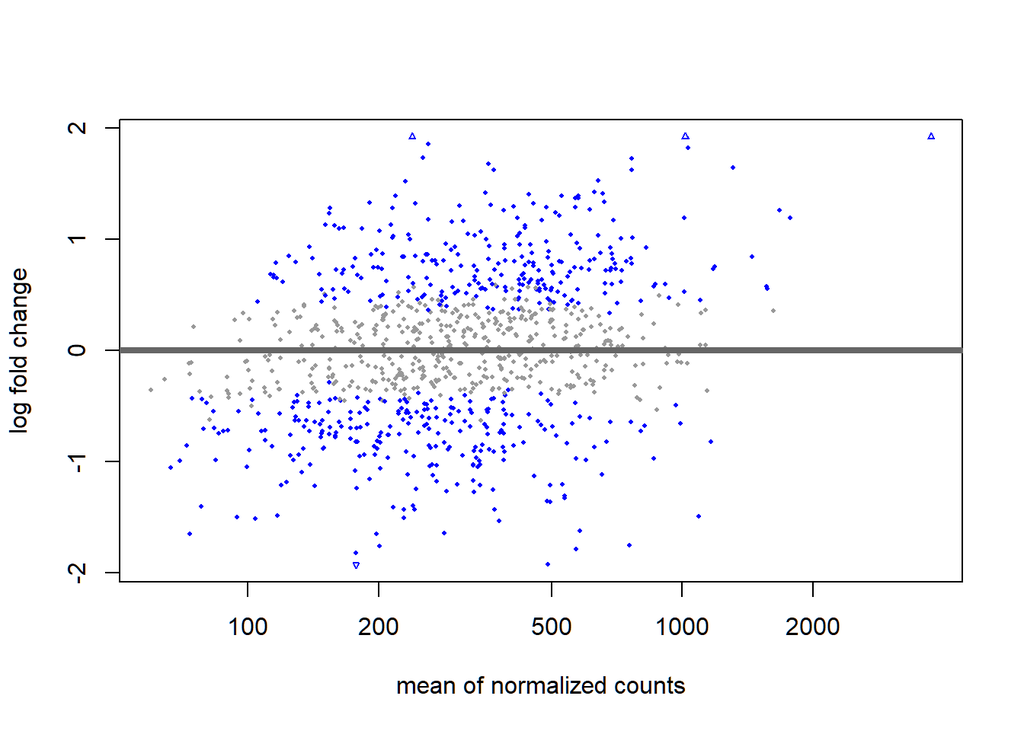

```r
DESeq2::plotMA(sex_avg)
```

This step shows how sex effects are extracted from an interaction model and why doing so requires care.

With the interaction design: Sex + Batch + Sex:Batch (or the equivalent Sex*Batch), DESeq2 outputs sex effects relative to a reference batch (here Batch A). As a result, the basic Sex contrast call (contrast = c(“Sex”, “xy”, “xx”)) returns the XY vs XX difference in Batch A only, and the addition of the interaction term (contrast = list(c(“Sex_xy_vs_xx”, “Sexxy.Batchb”))) gives the XY vs XX difference in Batch B.

Thus, DESeq2 does not directly return a single “overall” sex effect when an interaction is present: it returns batch-specific sex contrasts.

However, for most biological questions, we want the average sex effect across both batches. To obtain this, the contrast must be constructed manually from the model matrix. By averaging the design rows for XY and XX samples at day 0, we create a contrast that represents the mean XY–XX difference across both batches. The equivalent vector form is also shown and is equivalent, as it weights the main sex effect and half of the interaction term, which corresponds to averaging Batch A and Batch B sex differences if both batches are balanced.

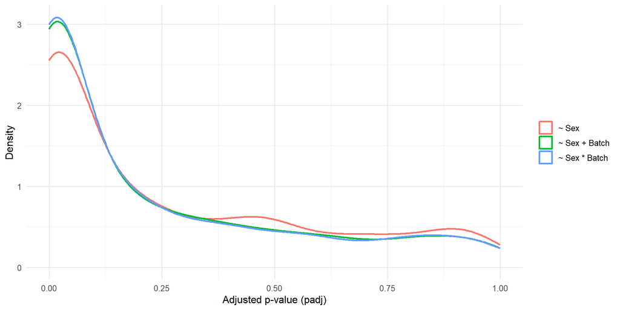

```r
padj_df <- tibble(
  gene = rownames(res_sex),
  `~ Sex`          = res_sex$padj,
  `~ Sex + Batch`  = res_sex_batch$padj,
  `~ Sex * Batch`  = sex_avg$padj
) %>%
  pivot_longer(-gene, names_to = "Model", values_to = "padj") %>%
  filter(!is.na(padj))

padj_df$Model <- factor(
  padj_df$Model,
  levels = c("~ Sex", "~ Sex + Batch", "~ Sex * Batch")
)

ggplot(padj_df, aes(x = padj, colour = Model)) +
  geom_density(linewidth = 1) +
  coord_cartesian(xlim = c(0, 1)) +
  labs(x = "Adjusted p-value (padj)", y = "Density") +
  theme_minimal(base_size = 12) +
  theme(legend.title = element_blank())
```

This density plot compares the distribution of adjusted p-values (padj) for the sex contrast under three models: ~ Sex, ~ Sex + Batch, and ~ Sex × Batch. Adding batch and then the batch × sex interaction slightly shifts the distribution toward lower padj values, indicating a modest increase in statistical power for detecting sex-dependent genes. However, the overall shape of the curves remains very similar across models, showing that most of the sex signal is already present in the simple ~ Sex model.

Now, let’s look at a specific gene to understand the calculations that are going on.

First, for G164, here is what DESeq2 sees when inlcuding only a Sex factor.

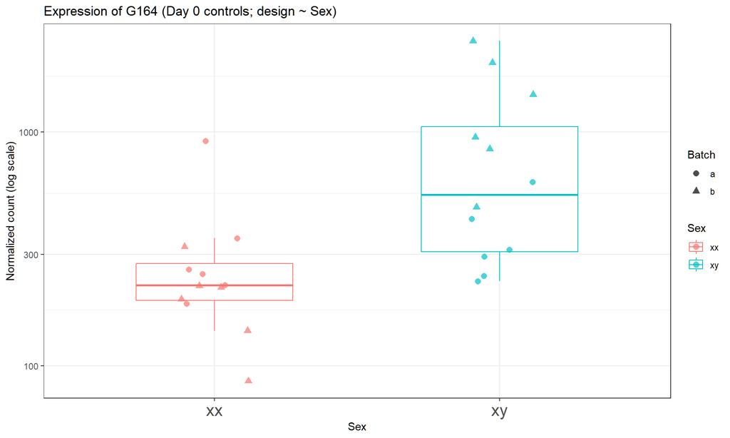

When the design is ~ Sex, DESeq2 collapses all samples into just two groups: XX and XY. In this first plot, both Batch A and Batch B samples are pooled within each sex, and the model estimates the sex effect by comparing the overall mean expression of XX versus XY.

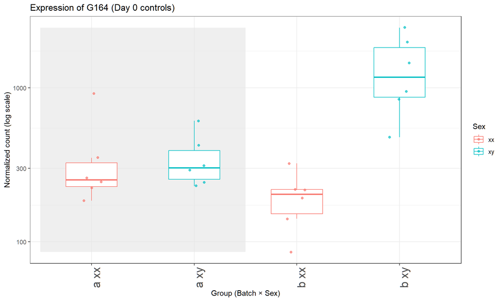

When a batch term is added, DESeq2 models expression separately for each Sex × Batch group, as shown in this second plot. This allows the model to distinguish sex differences from shifts caused by batch.

At day 0, XX controls differ slightly between batches: XX samples from Batch B show lower normalized counts than XX samples from Batch A, despite both groups being untreated controls.

XY controls are showing an inverse trend, with higher counts in Batch B, suggesting that the batch effect is sex-dependent for this gene.

Lets look at the results from contrasts using all 3 designs.

```r
out <- data.frame(
  Model = c("~ Sex",
            "~ Sex + Batch",
            "Sex averaged across batches",
            "Sex in Batch A (Sex*Batch model)",
            "Sex in Batch B (Sex*Batch model)"),
  LFC   = c(
    res_sex[selected_gene, "log2FoldChange"],
    res_sex_batch[selected_gene, "log2FoldChange"],
    sex_avg[selected_gene, "log2FoldChange"],
    sex_all_a[selected_gene, "log2FoldChange"],
    sex_all_b[selected_gene, "log2FoldChange"]
  ),
  padj  = c(
    res_sex[selected_gene, "padj"],
    res_sex_batch[selected_gene, "padj"],
    sex_avg[selected_gene, "padj"],
    sex_all_a[selected_gene, "padj"],
    sex_all_b[selected_gene, "padj"]
  )
)

out
```

| Model | LFC | padj |
| --- | --- | --- |
| ~ Sex | 1.61201980 | 5.130925e-04 |
| ~ Sex + Batch | 1.37229621 | 2.774904e-03 |
| Sex averaged across batches | 1.37245026 | 5.308438e-06 |
| Sex in Batch A (Sex*Batch model) | -0.04578688 | 9.559704e-01 |
| Sex in Batch B (Sex*Batch model) | 2.79068740 | 3.997456e-11 |

By contrast, the interaction model (~ Sex * Batch) allows sex to be aligned independently within each batch. This means that the XX–XY difference is estimated separately in Batch A and Batch B before being combined. The resulting batch-averaged sex effect therefore reflects a true biological difference that is consistent across growth contexts, rather than one driven by how the batches differ. This is why the sex-averaged estimate shows a stronger statistical support (much smaller adjusted p-value): the model has removed sex-specific batch distortions before testing the sex effect.

In a simple experiment designed only to measure sex differences, one would usually not need such a flexible model. If the gene is genuinely higher in one sex regardless of growth conditions, a single batch term (~ Sex + Batch) is typically sufficient to place all samples on the same scale and recover the correct sex effect.

However, in this study the situation is more complex. At day 1, treatments are applied to one sex in one batch while the other batch remains as control. This means that batch is no longer independent of biology, and sex-specific responses to the growth environment become intertwined with treatment effects. In that context, being able to align samples independently for each sex across batches is critical: it ensures that treatment effects are estimated on a properly matched baseline, increasing confidence that observed differences truly reflect the biological perturbation rather than residual batch structure.

This interaction-based modeling strategy provides a way to obtain LFC and adjusted p-values for every gene across the full experiment (including day-1 samples and treatment conditions) while explicitly accounting for both batch effects and their interaction with sex. DESeq2 can correctly attribute variation to sex, batch, and their interaction, yielding statistically valid effect sizes and significance values even in a complex, partially confounded design.

However, model-based inference alone is not always sufficient for interpretation. Many exploratory analyses (such as boxplots, heatmaps, clustering, and PCA) are easier to understand when they are performed on batch-corrected expression values rather than on raw or merely normalized counts. Moreover, many downstream analyses (e.g., gene networks) implicitly assume that samples are directly comparable. Residual batch structure in the data can strongly bias these approaches.

For this reason, we next apply two widely used batch-correction methods (limma’s removeBatchEffect and ComBat-seq) to remove unwanted batch-associated variation from the data.

# Part 1: Batch effect correction

## Limma’s removeBatchEffect and ComBat_seq as single batch corrections

For each correction method, we will regenerate the PCA and single-gene boxplot shown earlier. This allows us to directly compare how each approach reshapes the data, how effectively it aligns samples across batches, and how much biological structure (sex in the simple day-0 case) is preserved or distorted by each correction.

```r
counts0_mat <- as.matrix(counts0)

# VST for limma (recommended)
dds0 <- DESeqDataSetFromMatrix(counts0_mat, colData0, design = ~ Sex)
dds0 <- estimateSizeFactors(dds0)
vsd0 <- vst(dds0, blind = TRUE)

design_mat <- model.matrix(~ Sex, data = colData0)
vsd_limma <- assay(vsd0)
vsd_limma_corr <- removeBatchEffect(vsd_limma, batch = colData0$Batch, design = design_mat)

vsd_limma_sbc <- vsd0
assay(vsd_limma_sbc) <- vsd_limma_corr
```

```r
combat_counts <- ComBat_seq(
  counts = counts0_mat,
  batch  = colData0$Batch,
  group  = colData0$Sex
)
```

```
## Found 2 batches
## Using full model in ComBat-seq.
## Adjusting for 1 covariate(s) or covariate level(s)
## Estimating dispersions
## Fitting the GLM model
## Shrinkage off - using GLM estimates for parameters
## Adjusting the data
```

```r
dds_combat <- DESeqDataSetFromMatrix(combat_counts, colData0, design = ~ Sex)
dds_combat <- estimateSizeFactors(dds_combat)
vsd_combat <- vst(dds_combat, blind = TRUE)
```

```r
pca_limma <- plotPCA(
  vsd_limma_sbc,
  intgroup = c("Sex","Batch"),
  returnData = TRUE
)
```

```
## using ntop=500 top features by variance
```

```r
pca_combat <- plotPCA(
  vsd_combat,
  intgroup = c("Sex","Batch"),
  returnData = TRUE
)
```

```
## using ntop=500 top features by variance
```

```r
plot_pca <- function(pdat, title) {
  pv <- round(100 * attr(pdat, "percentVar"))
  ggplot(pdat, aes(PC1, PC2, colour = Sex, shape = Batch)) +
    geom_point(size = 4) +
    labs(x = paste0("PC1: ", pv[1], "%"),
         y = paste0("PC2: ", pv[2], "%"),
         title = title) +
    theme_bw()
}

pca0 <- plot_pca(pdat, "original data, day 0 samples")
pca1 <- plot_pca(pca_limma, "limma removeBatchEffect, day 0 samples")
pca2 <- plot_pca(pca_combat, "ComBat-seq, day 0 samples")
```

```r
plot_gene <- function(expr, gene, title) {
  df <- tibble(
    SampleID = colnames(expr),
    Expression = expr[gene,]
  ) %>%
    left_join(colData0, by = "SampleID") %>%
    mutate(Group = factor(paste(Batch, Sex),
                          levels = c("a xx","a xy","b xx","b xy")))

  ggplot(df, aes(Group, Expression, colour = Sex)) +
    geom_boxplot(outlier.shape = NA) +
    geom_jitter(width = .15, size = 2, alpha = .7) +
    scale_y_log10() +
    labs(title = title, y = "Expression", x = "Batch × Sex") +
    theme_bw() +
    theme(axis.text.x = element_text(angle = 90))
}

gene <- "G164"

box_raw <- plot_gene(assay(vsd0), gene, "Uncorrected G164")
box_limma  <- plot_gene(assay(vsd_limma_sbc), gene, "limma corrected G164")
box_combat <- plot_gene(assay(vsd_combat), gene, "ComBat-seq corrected G164")
```

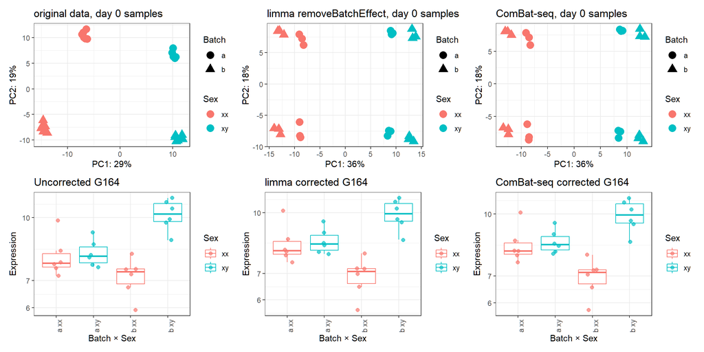

```r
(pca0 + pca1 + pca2) / (box_raw + box_limma + box_combat)
```

Both limma removeBatchEffect and ComBat-seq produce very similar corrections. In both cases, the PCA shows that the dominant separation between samples is no longer driven by batch, but instead reflects underlying biological structure, such as genotype (not shown here).

At the same time, small residual differences remain between biologically identical samples from different batches, indicating that neither method completely removes all batch-associated variation.

The boxplots for G164 confirm this: limma and ComBat-seq mainly shift batches toward a common mean, but they do not force XX and XY to align consistently across batches. For G164, the sex pattern within Batch A and within Batch B is largely preserved, so any sex-dependent batch offset remains. That is not sufficient for our study, because day-1 comparisons rely on day-0 baselines being comparable across batches. If XX and XY are not aligned across batches at day 0, treatment effects at day 1 can be confounded by residual batch × sex structure.

To address this, we introduce DESeq2-MultiBatch, which explicitly models and removes batch × biology interactions rather than only global batch shifts. Instead of assuming that batch affects all samples in the same way, MultiBatch allows the batch effect to differ between XX and XY, and corrects each group independently. This produces sex-aligned baselines across batches at day 0, which is exactly what is required for a time-dependent design where treatments are applied to one sex in one batch but not the other.

## Apply the correction

First, run the function MultiBatch

```r
MultiBatch <- function(
    dds,
    batch_factor,
    interact_factor = NULL,
    mode = c("center", "reference"),
    use_normalized = TRUE,
    round_out = TRUE,
    independentFiltering = FALSE,
    verbose = TRUE
) {
  stopifnot(is(dds, "DESeqDataSet"))
  mode <- match.arg(mode)

  rnames <- DESeq2::resultsNames(dds)
  cd <- as.data.frame(SummarizedExperiment::colData(dds))
  if (!batch_factor %in% names(cd))
    stop("batch_factor '", batch_factor, "' not found in colData(dds).")
  if (!is.null(interact_factor) && !interact_factor %in% names(cd))
    stop("interact_factor '", interact_factor, "' not found in colData(dds).")

  nc <- DESeq2::counts(dds, normalized = use_normalized)
  nc <- as.matrix(nc)
  G <- nrow(nc)

  bf <- as.factor(cd[[batch_factor]])
  b_levels <- levels(bf)
  if (is.null(b_levels) || length(b_levels) < 2)
    stop("Batch factor must have at least 2 levels.")
  b_ref <- b_levels[1]

  if (is.null(interact_factor)) {
    if (verbose) message("No interact_factor provided; adjusting Batch main effect only.")
    int_levels <- "(no-int)"
    i_ref <- "(no-int)"
    int_vec <- rep("(no-int)", nrow(cd))
  } else {
    intf <- as.factor(cd[[interact_factor]])
    int_levels <- levels(intf)
    i_ref <- int_levels[1]
    int_vec <- as.character(intf)
  }

  safe_lfc <- function(v) {
    v[is.na(v)] <- 0
    as.numeric(v)
  }

  get_lfc_by_name <- function(coef_name) {
    if (!(coef_name %in% rnames)) {
      if (verbose) message("  (missing coef) ", coef_name)
      return(rep(0, G))
    }
    res <- DESeq2::results(dds, name = coef_name, independentFiltering = independentFiltering)
    safe_lfc(res$log2FoldChange)
  }

  batch_coef_name <- function(batch_level) {
    paste0(batch_factor, "_", batch_level, "_vs_", b_ref)
  }

  interaction_coef_name <- function(b_lev, i_lev) {
    if (is.null(interact_factor) || b_lev == b_ref || i_lev == i_ref) return(NA_character_)
    candidates <- c(
      paste0(batch_factor, b_lev, ".", interact_factor, i_lev),
      paste0(interact_factor, i_lev, ".", batch_factor, b_lev)
    )
    hit <- candidates[candidates %in% rnames]
    if (length(hit) == 0) NA_character_ else hit[1]
  }

  if (verbose) message("Collecting main Batch coefficients relative to '", b_ref, "'...")
  main_batch_LFC <- vector("list", length(b_levels))
  names(main_batch_LFC) <- b_levels
  main_batch_LFC[[b_ref]] <- rep(0, G)
  for (bl in b_levels[b_levels != b_ref]) {
    nm <- batch_coef_name(bl)
    if (verbose) message("  ", nm)
    main_batch_LFC[[bl]] <- get_lfc_by_name(nm)
  }

  delta_by_intlevel <- vector("list", length(int_levels))
  names(delta_by_intlevel) <- int_levels

  if (is.null(interact_factor)) {
    M <- do.call(cbind, main_batch_LFC)
    colnames(M) <- b_levels
    delta_by_intlevel[[1]] <- M
  } else {
    if (verbose) message("Collecting Batch: ", interact_factor, " interaction coefficients...")
    for (il in int_levels) {
      # start from main batch effects
      M <- do.call(cbind, main_batch_LFC)
      colnames(M) <- b_levels

      if (il != i_ref) {
        for (bl in b_levels[b_levels != b_ref]) {
          nm_int <- interaction_coef_name(bl, il)
          if (!is.na(nm_int)) {
            if (verbose) message("  + ", nm_int)
            M[, bl] <- M[, bl] + get_lfc_by_name(nm_int)
          } else {
            if (verbose) message("  (no explicit coef for ", bl, "×", il, ")")
          }
        }
      }
      delta_by_intlevel[[il]] <- M
    }
  }

  if (verbose) message("Computing per-gene scaling factors (mode = '", mode, "').")
  scale_by_intlevel <- lapply(delta_by_intlevel, function(M) {
    if (mode == "center") {
      row_means <- rowMeans(M, na.rm = TRUE)
      sweep_M <- sweep(M, 1, row_means, FUN = "-")
      2^(-sweep_M)
    } else {
      2^(-M)
    }
  })

  if (verbose) message("Applying scaling factors to columns of the count matrix...")
  out <- nc
  sample_batches <- as.character(bf)
  for (j in seq_len(ncol(nc))) {
    bl <- sample_batches[j]
    il <- int_vec[j]
    if (is.null(interact_factor)) il <- "(no-int)"

    S <- scale_by_intlevel[[il]][, bl]
    out[, j] <- nc[, j] * S
  }

  if (round_out) {
    out <- round(out)
    storage.mode(out) <- "integer"
  }

  if (verbose) {
    message("Done.")
    message("Reference levels inferred from colData(): ",
            batch_factor, "='", b_ref, "'",
            if (!is.null(interact_factor)) paste0(", ", interact_factor, "='", i_ref, "'") else "")
  }

  list(
    adjusted_counts = out,
    scaling_tables = scale_by_intlevel,
    delta_tables   = delta_by_intlevel,
    batch_levels   = b_levels,
    interact_levels = int_levels,
    reference = list(batch = b_ref, interact = i_ref),
    mode = mode,
    used_results_names = rnames
  )
}
```

```r
# design
design_single <- ~ Batch + Sex

# construct a DESeqDataSet object
dds0_single <- DESeqDataSetFromMatrix(countData = counts0,
                                  colData = colData0,
                                  design = design_single)

# run DESeq
dds0_single <- DESeq(dds0_single)
```

```r
# design
design_double <- ~ Batch + Sex + Sex:Batch

# construct a DESeqDataSet object
dds0_double <- DESeqDataSetFromMatrix(countData = counts0,
                                  colData = colData0,
                                  design = design_double)

# run DESeq
dds0_double <- DESeq(dds0_double)
```

```r
adj0_s <- MultiBatch(
  dds0_single,
  batch_factor    = "Batch",
  interact_factor = NULL,
  mode = "center",
  use_normalized = TRUE,
  round_out = TRUE,
  verbose = TRUE)

scaled_counts0_single <- adj0_s$adjusted_counts
```

```r
adj0_d <- MultiBatch(
  dds0_double,
  batch_factor    = "Batch",
  interact_factor = "Sex",
  mode = "center",
  use_normalized = TRUE,
  round_out = TRUE,
  verbose = TRUE)

scaled_counts0_double <- adj0_d$adjusted_counts
```

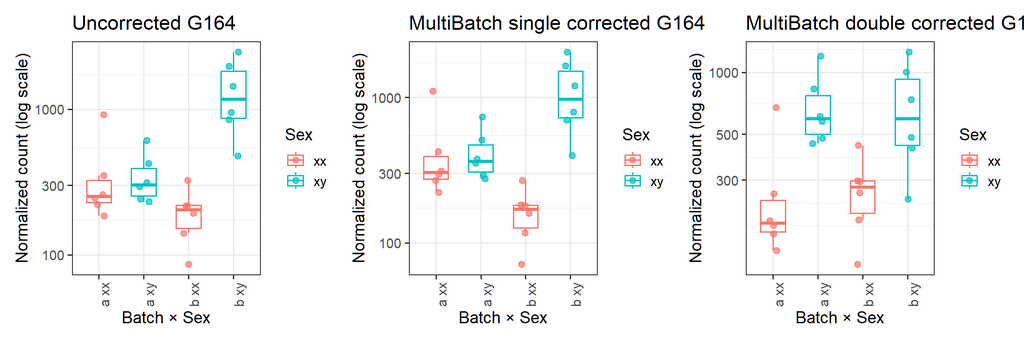

```r
# helper to build a boxplot from a counts matrix (genes x samples)
plot_gene_counts <- function(count_mat, gene, title) {

  df_box <- tibble(
    SampleID   = colnames(count_mat),
    Expression = as.numeric(count_mat[gene, ])
  ) %>%
    left_join(as.data.frame(colData0) %>% select(SampleID, Batch, Sex),
              by = "SampleID") %>%
    mutate(
      Group = factor(
        paste(tolower(as.character(Batch)), tolower(as.character(Sex)), sep = " "),
        levels = c("a xx", "a xy", "b xx", "b xy")
      )
    )

  ggplot(df_box, aes(x = Group, y = Expression, colour = Sex)) +
    geom_boxplot(outlier.shape = NA, width = 0.55) +
    geom_jitter(width = 0.12, size = 2.2, alpha = 0.7) +
    scale_y_log10() +
    labs(
      title = title,
      x     = "Batch × Sex",
      y     = "Normalized count (log scale)"
    ) +
    theme_bw(base_size = 14) +
    theme(axis.text.x = element_text(angle = 90, hjust = 1))
}

# --- matrices to plot ---
raw_norm <- counts(dds_all0, normalized = TRUE)   # uncorrected baseline (Day 0)
single_scaled <- as.matrix(scaled_counts0_single) # MultiBatch single correction
double_scaled <- as.matrix(scaled_counts0_double) # MultiBatch double correction

# --- plots ---
p_raw    <- plot_gene_counts(raw_norm,      gene, "Uncorrected G164")
p_single <- plot_gene_counts(single_scaled, gene, "MultiBatch single corrected G164")
p_double <- plot_gene_counts(double_scaled, gene, "MultiBatch double corrected G164")

# 3 columns, like your limma/ComBat comparison
p_raw + p_single + p_double
```

## Diagnostic tool : choosing between single batch factor or interaction term

It is possible to quantify the degree of similarity of batch effects on female and male plants by either looking at the residual distances when correcting for a single batch factor, or by plotting the log 2 fold changes caused by batch effect in female and males of all genes.

```r
# construct a DESeqDataSet object
dds0_single_adj <- DESeqDataSetFromMatrix(countData = scaled_counts0_single,
                                  colData = colData0,
                                  design = design_double)

# run DESeq
dds0_single_adj <- DESeq(dds0_single_adj)
```

```r
# construct a DESeqDataSet object
dds0_double_adj <- DESeqDataSetFromMatrix(countData = scaled_counts0_double,
                                  colData = colData0,
                                  design = design_double)

# run DESeq
dds0_double_adj <- DESeq(dds0_double_adj)
```

```r
# get the model matrix
mod_mat <- model.matrix(design(dds_all0), colData(dds_all0))

# define the groups you wish to compare by calling columns info
xy_0a <- colMeans(mod_mat[dds_all0$Sex == "xy" & dds_all0$Batch == "a", ])
xy_0b <- colMeans(mod_mat[dds_all0$Sex == "xy" & dds_all0$Batch == "b", ])
xx_0a <- colMeans(mod_mat[dds_all0$Sex == "xx" & dds_all0$Batch == "a", ])
xx_0b <- colMeans(mod_mat[dds_all0$Sex == "xx" & dds_all0$Batch == "b", ])

xy_comp <- results(dds_all0, contrast = xy_0b - xy_0a, independentFiltering = FALSE)
xx_comp <- results(dds_all0, contrast = xx_0b - xx_0a, independentFiltering = FALSE)

summary(xy_comp)
```

```
##
## out of 1000 with nonzero total read count
## adjusted p-value < 0.1
## LFC > 0 (up)       : 164, 16%
## LFC < 0 (down)     : 144, 14%
## outliers [1]       : 0, 0%
## low counts [2]     : 0, 0%
## (mean count < 0)
## [1] see 'cooksCutoff' argument of ?results
## [2] see 'independentFiltering' argument of ?results
```

```r
summary(xx_comp)
```

```
##
## out of 1000 with nonzero total read count
## adjusted p-value < 0.1
## LFC > 0 (up)       : 172, 17%
## LFC < 0 (down)     : 162, 16%
## outliers [1]       : 0, 0%
## low counts [2]     : 0, 0%
## (mean count < 0)
## [1] see 'cooksCutoff' argument of ?results
## [2] see 'independentFiltering' argument of ?results
```

```r
# get the model matrix
mod_mat <- model.matrix(design(dds0_single_adj), colData(dds0_single_adj))

# define the groups you wish to compare by calling columns info
xy_0a <- colMeans(mod_mat[dds0_single_adj$Sex == "xy" & dds0_single_adj$Batch == "a", ])
xy_0b <- colMeans(mod_mat[dds0_single_adj$Sex == "xy" & dds0_single_adj$Batch == "b", ])
xx_0a <- colMeans(mod_mat[dds0_single_adj$Sex == "xx" & dds0_single_adj$Batch == "a", ])
xx_0b <- colMeans(mod_mat[dds0_single_adj$Sex == "xx" & dds0_single_adj$Batch == "b", ])

xy_comp_s <- results(dds0_single_adj, contrast = xy_0b - xy_0a, independentFiltering = FALSE)
xx_comp_s <- results(dds0_single_adj, contrast = xx_0b - xx_0a, independentFiltering = FALSE)

summary(xy_comp_s)
```

```
##
## out of 1000 with nonzero total read count
## adjusted p-value < 0.1
## LFC > 0 (up)       : 12, 1.2%
## LFC < 0 (down)     : 13, 1.3%
## outliers [1]       : 0, 0%
## low counts [2]     : 0, 0%
## (mean count < 0)
## [1] see 'cooksCutoff' argument of ?results
## [2] see 'independentFiltering' argument of ?results
```

```r
summary(xx_comp_s)
```

```
##
## out of 1000 with nonzero total read count
## adjusted p-value < 0.1
## LFC > 0 (up)       : 14, 1.4%
## LFC < 0 (down)     : 12, 1.2%
## outliers [1]       : 0, 0%
## low counts [2]     : 0, 0%
## (mean count < 0)
## [1] see 'cooksCutoff' argument of ?results
## [2] see 'independentFiltering' argument of ?results
```

```r
# get the model matrix
mod_mat <- model.matrix(design(dds0_double_adj), colData(dds0_double_adj))

# define the groups you wish to compare by calling columns info
xy_0a <- colMeans(mod_mat[dds0_double_adj$Sex == "xy" & dds0_double_adj$Batch == "a", ])
xy_0b <- colMeans(mod_mat[dds0_double_adj$Sex == "xy" & dds0_double_adj$Batch == "b", ])
xx_0a <- colMeans(mod_mat[dds0_double_adj$Sex == "xx" & dds0_double_adj$Batch == "a", ])
xx_0b <- colMeans(mod_mat[dds0_double_adj$Sex == "xx" & dds0_double_adj$Batch == "b", ])

xy_comp_d <- results(dds0_double_adj, contrast = xy_0b - xy_0a, independentFiltering = FALSE)
xx_comp_d <- results(dds0_double_adj, contrast = xx_0b - xx_0a, independentFiltering = FALSE)

summary(xy_comp_d)
```

```
##
## out of 1000 with nonzero total read count
## adjusted p-value < 0.1
## LFC > 0 (up)       : 0, 0%
## LFC < 0 (down)     : 0, 0%
## outliers [1]       : 0, 0%
## low counts [2]     : 0, 0%
## (mean count < 0)
## [1] see 'cooksCutoff' argument of ?results
## [2] see 'independentFiltering' argument of ?results
```

```r
summary(xx_comp_d)
```

```
##
## out of 1000 with nonzero total read count
## adjusted p-value < 0.1
## LFC > 0 (up)       : 0, 0%
## LFC < 0 (down)     : 0, 0%
## outliers [1]       : 0, 0%
## low counts [2]     : 0, 0%
## (mean count < 0)
## [1] see 'cooksCutoff' argument of ?results
## [2] see 'independentFiltering' argument of ?results
```

```r
vsd_raw    <- vst(dds_all0, blind = TRUE)
vsd_single <- vst(dds0_single_adj, blind = TRUE)
vsd_double <- vst(dds0_double_adj, blind = TRUE)
```

```r
batch_distance <- function(vsd, coldata) {

  pca <- prcomp(t(assay(vsd)))

  df <- data.frame(
    PC1   = pca$x[,1],
    PC2   = pca$x[,2],
    Sex   = coldata$Sex,
    Batch = coldata$Batch
  )

  dist_one <- function(sex) {
    a <- colMeans(df[df$Sex==sex & df$Batch=="a", c("PC1","PC2")])
    b <- colMeans(df[df$Sex==sex & df$Batch=="b", c("PC1","PC2")])
    sqrt(sum((a-b)^2))
  }

  data.frame(
    Metric = "Euclidean distance, Batch A v. B centroids in PCA space",
    XX = dist_one("xx"),
    XY = dist_one("xy")
  )
}

dist_raw    <- batch_distance(vsd_raw, colData0)
dist_single <- batch_distance(vsd_single, colData0)
dist_double <- batch_distance(vsd_double, colData0)

pca_distances <- rbind(
  Raw    = dist_raw,
  Single = dist_single,
  Double = dist_double
)

pca_distances
```

|  | Metric | XX | XY |
| --- | --- | --- | --- |
| Raw | Euclidean distance, Batch A v. B centroids in PCA space | 22.09784829 | 18.9119478 |
| Single | Euclidean distance, Batch A v. B centroids in PCA space | 4.31068181 | 4.3441040 |
| Double | Euclidean distance, Batch A v. B centroids in PCA space | 0.06843725 | 0.2109185 |

```r
expr_distance <- function(vsd, coldata) {

  mat <- assay(vsd)

  mean_expr <- function(sex, batch) {
    rowMeans(mat[, coldata$Sex==sex & coldata$Batch==batch])
  }

  d <- function(sex) {
    a <- mean_expr(sex,"a")
    b <- mean_expr(sex,"b")
    sqrt(mean((a-b)^2))
  }

  data.frame(
    Metric = "RMS difference of mean expression, Batch A v. B (all genes)",
    XX = d("xx"),
    XY = d("xy")
  )
}

expr_distances <- rbind(
  Raw    = expr_distance(vsd_raw, colData0),
  Single = expr_distance(vsd_single, colData0),
  Double = expr_distance(vsd_double, colData0)
)

expr_distances
```

|  | Metric | XX | XY |
| --- | --- | --- | --- |
| Raw | RMS difference of mean expression, Batch A v. B (all genes) | 0.76953537 | 0.70319779 |
| Single | RMS difference of mean expression, Batch A v. B (all genes) | 0.36918095 | 0.36771846 |
| Double | RMS difference of mean expression, Batch A v. B (all genes) | 0.08188914 | 0.08898808 |

These two metrics quantify the same biological question viewed from two perspectives: how far apart are biologically identical samples (including only Sex as grouping) from different batches once projected into expression space?

In the first table, the numbers represent the Euclidean distance between the centroids of Batch A and Batch B for a given sex, measured in the space of the first two principal components.

The second table computes the root-mean-square difference in gene expression for each sex between Batch A and Batch B across all genes. This metric lives in full gene-expression space, not just PC space. It measures how different the average transcriptome profiles are between batches.

After accounting for the modeled effects (sex, batch, and their interaction), the residuals represent the portion of gene expression that is not explained by these factors. This remaining variation includes genotype differences (not included in this example) and other unmodeled environmental or technical effects, as well as intrinsic noise measurements.

Together, the batch-separation distances and the number of DEGs between biologically identical groups provide a practical framework for deciding whether an interaction term is required in a batched study.

If batch A and B remain far apart in PCA or expression space, or if many genes are still detected as differentially expressed between identical groups, then a simple additive batch term is insufficient and a batch × biology interaction should be modelled.

Conversely, if both the geometric distances and the DEG counts collapse toward zero after single-batch correction, a simpler model may be adequate. In this way, these metrics offer a data-driven criterion to justify when interaction-aware batch correction is necessary.

# Part 2: Multi-factorial Analyses

The complete experimental design involves dioecious plants undergoing sex-specific treatments.

Samples were harvested at two distinct time points: day 0 (vegetative) and day 1 (early flowering). Due to treatments to alter flower sex, male and female plants were separated (needing batched experiment):

Batch A: Female controls (n=6) and treated males (n=6)

Batch B: Male controls (n=6) and treated females (n=6)

The treatments were applied following day 0 sampling but before day 1 sampling, allowing day 0 data to serve as a baseline for controlling batch effects.

Samples were collected across two genotypes (or cultivars), with three biological replicates per combination of sex, treatment, genotype, batch and time point.

Additionally, the length of photoperiod is changed in-between day 0 and day 1 to induce flowering.

An overview of the experimental setup is seen below. Note that it does not include the genotype information for simplicity.

We could use the data to look at :

1. The main effects of interest in this study, which are the treatments;
2. Sex differences in gene expression for vegetative plants (“xx day 0 control” v. “xy day 0 control”);
3. Sex differences in gene expression in early-flowering plants (“xx day 1 control” v. “xy day 1 control”);
4. Change in gene expression induced by the change in photoperiod for both sexes (biologically, we expect different effects on females and males);
5. Genotype differences in gene expression (intra-species variability);
6. Differential effect of treatment across genotypes (variability of treatment response).

Similarly, since we expect the photoperiod change to affect plants based on Sex, a Sex:Day factor is required, but colData could also have days labelled as 0, 1a (for females) and 1b (for males) to remove this interaction term.

Having both methods here allows to understand how to proceed in each case (see part 2).

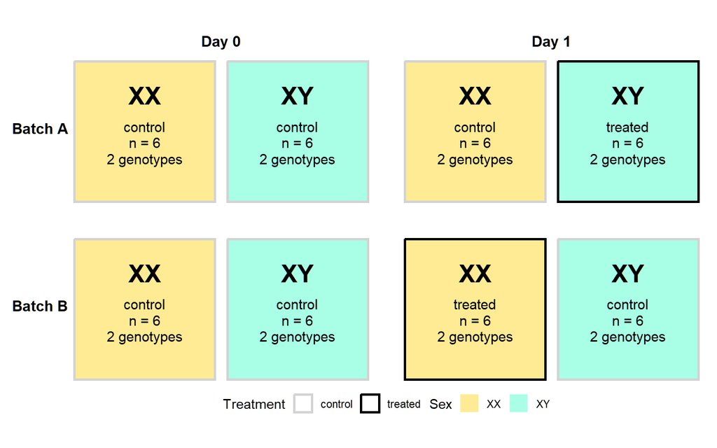

## Loading data files

```r
# load metadata
colData <- read.csv(file = "coldata.csv")
colData[,2:6] <- lapply(colData[,2:6], as.factor)

# load counts
counts <- read.csv(file = "counts.csv", check.names = FALSE, row.names = 1)
```

## Running DESeq2 with various designs

```r
# design
design <- ~ Day + Sex + Sex:Day + Treatment

# construct a DESeqDataSet object
dds <- DESeqDataSetFromMatrix(countData = counts,
                                  colData = colData,
                                  design = design)

dds <- DESeq(dds)

resultsNames(dds)
```

```
## [1] "Intercept"                "Day_1_vs_0"
## [3] "Sex_xy_vs_xx"             "Treatment_treat1_vs_ctrl"
## [5] "Treatment_treat2_vs_ctrl" "Day1.Sexxy"
```

```r
colData
```

| SampleID | Genotype | Sex | Day | Batch | Treatment |
| --- | --- | --- | --- | --- | --- |
| Sample1 | c1 | xx | 0 | a | ctrl |
| Sample2 | c1 | xx | 0 | a | ctrl |
| Sample3 | c1 | xx | 0 | a | ctrl |
| Sample4 | c2 | xx | 0 | a | ctrl |
| Sample5 | c2 | xx | 0 | a | ctrl |
| Sample6 | c2 | xx | 0 | a | ctrl |
| Sample7 | c1 | xy | 0 | a | ctrl |
| Sample8 | c1 | xy | 0 | a | ctrl |
| Sample9 | c1 | xy | 0 | a | ctrl |
| Sample10 | c2 | xy | 0 | a | ctrl |

[output cut: 38 more lines]

As you can see, the treatments are denoted “treat1” and “treat2”. It could be simply “treat” for both sexes, but it would require the interaction “Treatment:Sex” to allow for independent effects of masculinisation and feminisation.

Similarly, since we expect the photoperiod change to affect plants based on Sex, a Sex:Day factor is required, but colData could also have days labelled as 0, 1a (for females) and 1b (for males) to remove this interaction term.

Having both methods here allows to understand how to proceed in each case.

First, just like in part 1, lets take as an example a gene that shows an interesting behaviour across days, sex and treatments.

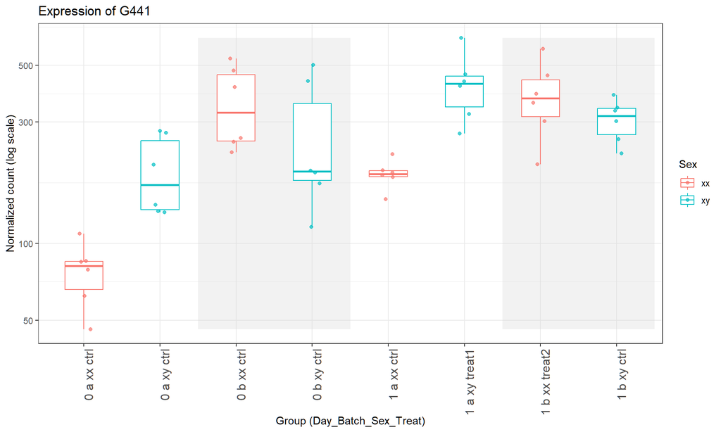

And, like in part 1, lets look at the data for XX samples as seen by DESeq2 if we exclude the batch factor.

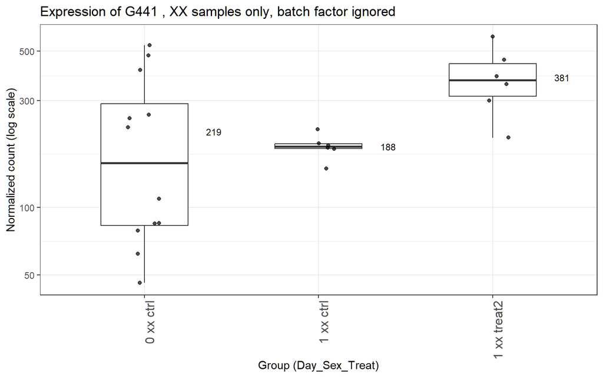

We can see that DESeq2 would use **all** XX controls at day 0 to find a baseline expression value, then would compare this value with the XX control samples at day 1 to get the effect of photoperiod change (day).

Then, XX treated compared to XX control samples at day 1 show the effect of treatment on female plants.

Here, with the average expression shown, we can already predict that the effect of the photoperiod change (control XX at day 1 v. control XX at day 0) will be minimal (LFC close to 0).

The effect of the treatment will be roughly LFC = 1 (the expression approximately doubles from 188 to 381).

```r
day_effect <- results(dds, name = "Day_1_vs_0", independentFiltering = FALSE)
day_effect[441,]
```

```
## log2 fold change (MLE): Day 1 vs 0
## Wald test p-value: Day 1 vs 0
## DataFrame with 1 row and 6 columns
##       baseMean log2FoldChange     lfcSE      stat    pvalue      padj
##      <numeric>      <numeric> <numeric> <numeric> <numeric> <numeric>
## G441   274.793      -0.222236   0.35331 -0.629011  0.529342  0.667518
```

```r
trt2_effect <- results(dds, name = "Treatment_treat2_vs_ctrl", independentFiltering = FALSE)
trt2_effect[441,]
```

```
## log2 fold change (MLE): Treatment treat2 vs ctrl
## Wald test p-value: Treatment treat2 vs ctrl
## DataFrame with 1 row and 6 columns
##       baseMean log2FoldChange     lfcSE      stat    pvalue      padj
##      <numeric>      <numeric> <numeric> <numeric> <numeric> <numeric>
## G441   274.793        1.02375  0.407072   2.51491 0.0119064 0.0351221
```

As expected, LFCs of about -0.2 and 1.0 for day and treatment, respectively. The treatment has an effect on gene expression (padj = 0.035).

Now, lets look at the data as seen by DESeq2 if we include the batch factor.

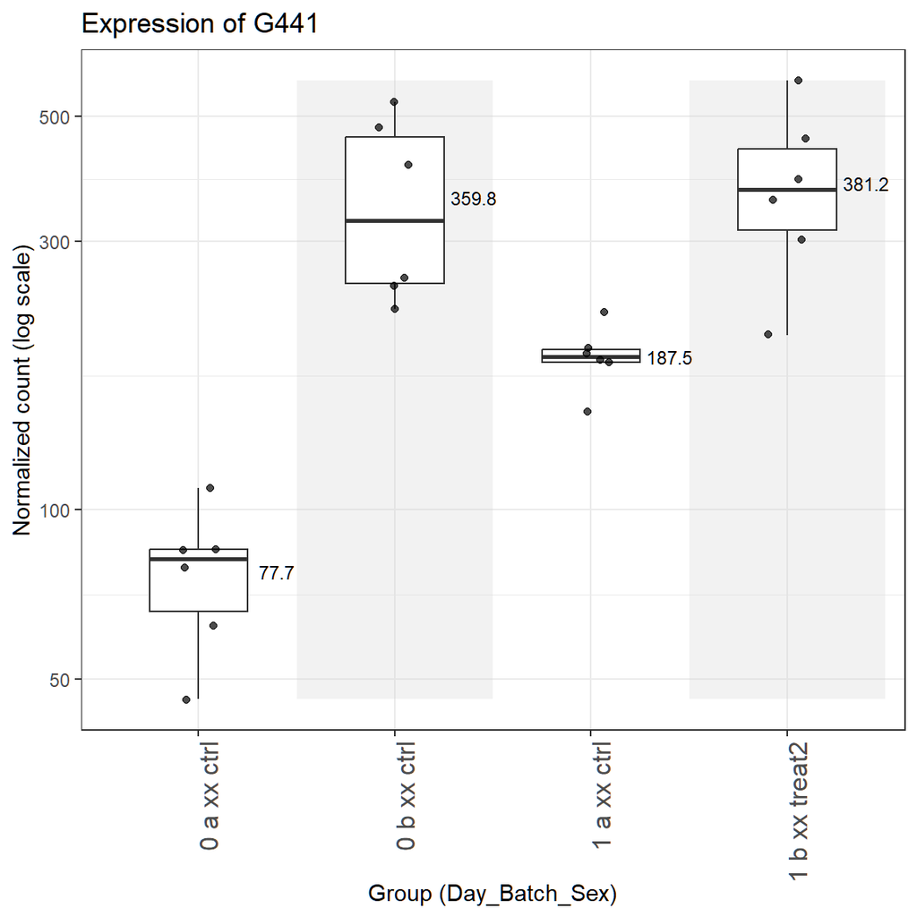

DESeq2 can extract the effect of the change in photoperiod using XX samples from batch A (controls, only received the photoperiod change).

Here, we can approximate this day effect with 188/78 for a LFC of about 1.3.

Then, if we assume that the change in photoperiod affects XX samples the same way across batches, the treatment effect would be the difference between the expected value from XX samples in batch B when the photoperiod effect is applied and the value from treated XX samples.

Let’s apply the photoperiod LFC of 1.3 to the XX samples from batch B : 360 * 2^1.3 = 886.

In other words, if XX samples from batch B were not treated, we would expect their average expression to be around 886.

The treatment effect would then be the LFC from 886/381, which is about -1.2.

This assumes that there are not interactions between the photoperiod change and the treatment.

Can we get these expected results by adding a batch factor to the design ?

```r
design <- ~ Day + Batch + Sex + Sex:Day + Treatment

dds <- DESeqDataSetFromMatrix(countData = counts,
                                  colData = colData,
                                  design = design)

dds <- DESeq(dds)
```

```r
day_effect <- results(dds, name = "Day_1_vs_0", independentFiltering = FALSE)
day_effect[441,]
```

```
## log2 fold change (MLE): Day 1 vs 0
## Wald test p-value: Day 1 vs 0
## DataFrame with 1 row and 6 columns
##       baseMean log2FoldChange     lfcSE      stat    pvalue      padj
##      <numeric>      <numeric> <numeric> <numeric> <numeric> <numeric>
## G441   274.793       0.758505  0.313468   2.41972 0.0155325 0.0543872
```

```r
trt2_effect <- results(dds, name = "Treatment_treat2_vs_ctrl", independentFiltering = FALSE)
trt2_effect[441,]
```

```
## log2 fold change (MLE): Treatment treat2 vs ctrl
## Wald test p-value: Treatment treat2 vs ctrl
## DataFrame with 1 row and 6 columns
##       baseMean log2FoldChange     lfcSE      stat    pvalue      padj
##      <numeric>      <numeric> <numeric> <numeric> <numeric> <numeric>
## G441   274.793      -0.308502  0.408033 -0.756071  0.449606  0.666583
```

Instead of 1.3 and -1.2, we get 0.75 and -0.3. This is because the model adjusts for a single batch effect and, for this gene, it is not homogeneous across sex (remember that XY samples had little batch effect for G441).

Now, let’s look at the last design that includes both a batch factor and an interaction term Sex:Batch, which allows the model to fit a separate effect of batch on XY independently from the effect of batch on XX (base level, which means the batch effect without interaction represent the effect on XX).

```r
design <- ~ Day + Batch + Sex + Sex:Batch + Sex:Day + Treatment

dds <- DESeqDataSetFromMatrix(countData = counts,
                                  colData = colData,
                                  design = design)

dds <- DESeq(dds)
```

```r
day_effect <- results(dds, name = "Day_1_vs_0", independentFiltering = FALSE)
day_effect[441,]
```

```
## log2 fold change (MLE): Day 1 vs 0
## Wald test p-value: Day 1 vs 0
## DataFrame with 1 row and 6 columns
##       baseMean log2FoldChange     lfcSE      stat      pvalue        padj
##      <numeric>      <numeric> <numeric> <numeric>   <numeric>   <numeric>
## G441   274.793        1.27074  0.294593   4.31356 1.60648e-05 0.000254997
```

```r
trt2_effect <- results(dds, name = "Treatment_treat2_vs_ctrl", independentFiltering = FALSE)
trt2_effect[441,]
```

```
## log2 fold change (MLE): Treatment treat2 vs ctrl
## Wald test p-value: Treatment treat2 vs ctrl
## DataFrame with 1 row and 6 columns
##       baseMean log2FoldChange     lfcSE      stat     pvalue      padj
##      <numeric>      <numeric> <numeric> <numeric>  <numeric> <numeric>
## G441   274.793       -1.18696   0.41132  -2.88573 0.00390508 0.0610168
```

This way, we do find the expected values of about 1.3 (photoperiod change) and -1.2 (treatment on XX) we expected.

It’s worth noting that the padj value of 0.06 is less significant than the result obtained without batch factors, even if the pvalue itself is lower. Additional factors in the design will affect the pvalues of contrasts, as the degrees of freedom depend on the amount of factors.

## Contrast Calling

```r
# design
design <- ~ Day + Batch + Genotype + Sex + Sex:Batch + Sex:Day + Treatment

# construct a DESeqDataSet object
dds <- DESeqDataSetFromMatrix(countData = counts,
                                  colData = colData,
                                  design = design)

# specify reference levels
dds$Genotype <- relevel(dds$Genotype, ref = "c1")
dds$Sex <- relevel(dds$Sex, ref = "xx")
dds$Batch <- relevel(dds$Batch, ref = "a")
dds$Day <- relevel(dds$Day, ref = "0")
dds$Treatment <- relevel(dds$Treatment, ref = "ctrl")

# Run DESeq
dds <- DESeq(dds)
```

**There are multiple ways to call for a contrast of interest**

For most of these examples, *G441* will be used as an example gene, since it shows clear patterns for most factors.

Since the reference level (relevel) are sex xx, day 0, batch a, genotype c1 and ctrl, any call for contrast starts at this intercept.

### Example 1 : Effect of Photoperiod Change

#### Using resultsNames : name =, contrast =, and list

Here, let’s first extract the effect of photoperiod change on females and males.

This is straightforward, but requires using the interaction term.

```
## [1] "Intercept"                "Day_1_vs_0"
## [3] "Batch_b_vs_a"             "Genotype_c2_vs_c1"
## [5] "Sex_xy_vs_xx"             "Treatment_treat1_vs_ctrl"
## [7] "Treatment_treat2_vs_ctrl" "Batchb.Sexxy"
## [9] "Day1.Sexxy"
```

By adding Sex:Day in the design, the model has a coefficient for the effect of day for females and males. Calling for contrast name = “Day_1_vs_0” will output the change in gene expression from control female flowers at day 1 v. control female flowers at day 0. It will consider both genotypes equally, however, since we did not provide a Genotype:Day term.

```r
# coefficient name (contrast) for day change (photoperiod change) outputs effect on females
day_xx <- results(dds, name = "Day_1_vs_0", independentFiltering = FALSE)
day_xx[441,]
```

```
## log2 fold change (MLE): Day 1 vs 0
## Wald test p-value: Day 1 vs 0
## DataFrame with 1 row and 6 columns
##       baseMean log2FoldChange     lfcSE      stat      pvalue       padj
##      <numeric>      <numeric> <numeric> <numeric>   <numeric>  <numeric>
## G441   274.793        1.26935   0.29189   4.34872 1.36933e-05 0.00016498
```

If we want to answer “*what is the effect of photoperiod change on male flowers?*”, both the Day coefficient and the Sex:Day interaction coefficient must be considered.

This can be done with a list of contrasts.

```r
# coefficient name (contrast) for interaction term
int_day <- results(dds, name = "Day1.Sexxy", independentFiltering = FALSE)
int_day[441,]
```

```
## log2 fold change (MLE): Day1.Sexxy
## Wald test p-value: Day1.Sexxy
## DataFrame with 1 row and 6 columns
##       baseMean log2FoldChange     lfcSE      stat     pvalue      padj
##      <numeric>      <numeric> <numeric> <numeric>  <numeric> <numeric>
## G441   274.793       -1.07315  0.408092  -2.62968 0.00854641 0.0872082
```

```r
# coefficient name (contrast) for day change (photoperiod change) outputs effect on males
day_xy <- results(dds, contrast=list(c("Day_1_vs_0","Day1.Sexxy")), independentFiltering = FALSE)
day_xy[441,]
```

```
## log2 fold change (MLE): Day_1_vs_0+Day1.Sexxy effect
## Wald test p-value: Day_1_vs_0+Day1.Sexxy effect
## DataFrame with 1 row and 6 columns
##       baseMean log2FoldChange     lfcSE      stat    pvalue      padj
##      <numeric>      <numeric> <numeric> <numeric> <numeric> <numeric>
## G441   274.793       0.196196    0.2852  0.687924  0.491501  0.635836
```

Here are the expression levels for G441, for control plants, only including those who remained control at day 1 (half of the samples)

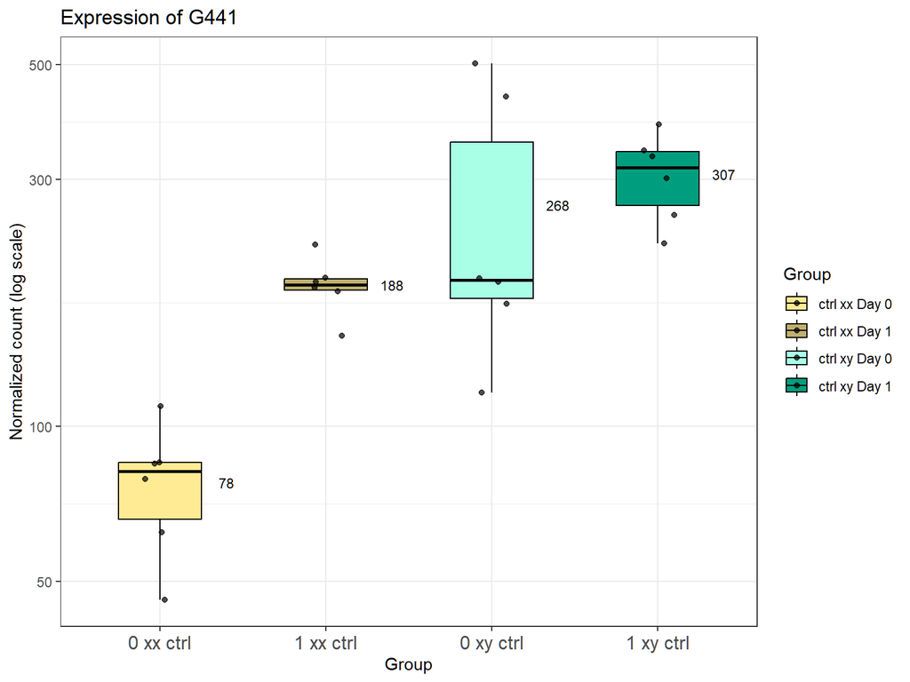

The LFC found for photoperiod effect on females (1.27) matches the expected value (78 to 188), as does the LFC for males (0.20), where the average count went from 268 to 307. The interaction term (-1.07) represents the difference between the latter and the former.

In simple terms, “Day_1_vs_0” (1.27) is applied to both males and females, while the interaction “Day1.Sexxy” (-1.07) allows to account for a different effect on males. The sum of both gives the effect of photoperiod change on males.

#### Using the Model Matrix

**The second way to call for contrasts involves using the model matrix to create groups**

Note that the comparison is done from the first group over the second : group A v. group B will show the ratio of expression of A over B.

Here, let’s compare control day 1 males to control males at day 0, hoping once again to extract the effect of photoperiod change on males.

Credit to Hugo Tavares from the BTF at Cambridge, read his explanations here : https://github.com/tavareshugo/tutorial_DESeq2_contrasts

```r
# get the model matrix
mod_mat <- model.matrix(design(dds), colData(dds))

# define the groups you wish to compare by calling columns info
xy_0 <- colMeans(mod_mat[dds$Sex == "xy" & dds$Day == "0" & dds$Treatment == "ctrl", ])
xy_1 <- colMeans(mod_mat[dds$Sex == "xy" & dds$Day == "1" & dds$Treatment == "ctrl", ])

day_xy <- results(dds, contrast = xy_1 - xy_0, independentFiltering = FALSE)
day_xy[441,]
```

```
## log2 fold change (MLE): 0,+1,+0.5,0,0,0,0,+0.5,+1
## Wald test p-value: 0,+1,+0.5,0,0,0,0,+0.5,+1
## DataFrame with 1 row and 6 columns
##       baseMean log2FoldChange     lfcSE      stat    pvalue      padj
##      <numeric>      <numeric> <numeric> <numeric> <numeric> <numeric>
## G441   274.793        0.43281  0.247179     1.751 0.0799461  0.138555
```

Weirdly, it doesn’t provide the same value as in the first example (0.43 instead of 0.20).

This is because this method uses all factors affecting the samples from the group. As the batch was not specified, it uses all male samples at day 0, since they are all control.

This can be seen in the output :

“log2 fold change (MLE): 0,+1,+0.5,0,0,0,0,+0.5,+1”

The third and before-last columns from the model matrix refer the the Batch and Batch:Sex factors. They are halved because half the samples belong to the batch B. If we had done the same thing, but for female samples, the third term would also be 0.5, but the before-last would be 0 since the interaction term does not apply to the reference levels (here, xx).

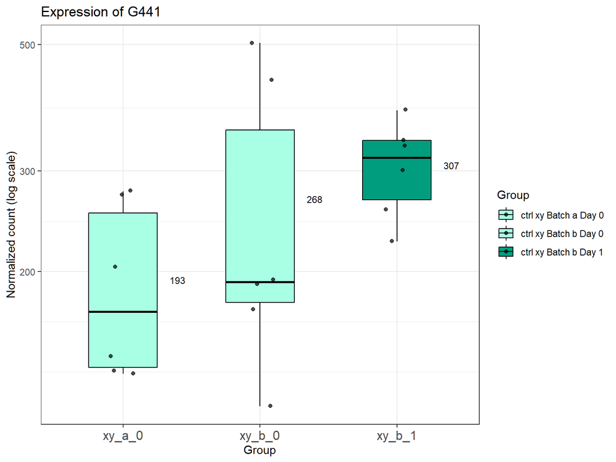

This shows what the model uses : both batches at day 0, and the controls from batch b at day 1.

Like in the first example, let’s extract the Batch effect for males using the Batch and the Batch:Sex factor

```r
batch_xy <- results(dds, contrast=list(c("Batch_b_vs_a","Batchb.Sexxy")), independentFiltering = FALSE)
batch_xy[441,]
```

```
## log2 fold change (MLE): Batch_b_vs_a+Batchb.Sexxy effect
## Wald test p-value: Batch_b_vs_a+Batchb.Sexxy effect
## DataFrame with 1 row and 6 columns
##       baseMean log2FoldChange     lfcSE      stat    pvalue      padj
##      <numeric>      <numeric> <numeric> <numeric> <numeric> <numeric>
## G441   274.793       0.473228  0.286363   1.65255 0.0984225  0.213036
```

The LFC (0.47) is consistent with the count values (193 to 268).

Half of this result (0.235) is added to the “true” photoperiod change : 0.20 + 0.235 is around 0.43, as seen in the first incorrect result.

This can be fixed by being specific when defining groups

```r
# define control males at day 1 and control (all) males at day 0
xy_1 <- colMeans(mod_mat[dds$Sex == "xy" & dds$Day == "1" & dds$Treatment == "ctrl", ])
xy_0 <- colMeans(mod_mat[dds$Sex == "xy" & dds$Day == "0" & dds$Batch == "b", ])

day_xy <- results(dds, contrast = xy_1 - xy_0, independentFiltering = FALSE)
day_xy[441,]
```

```
## log2 fold change (MLE): 0,+1,0,0,0,0,0,0,+1
## Wald test p-value: 0,+1,0,0,0,0,0,0,+1
## DataFrame with 1 row and 6 columns
##       baseMean log2FoldChange     lfcSE      stat    pvalue      padj
##      <numeric>      <numeric> <numeric> <numeric> <numeric> <numeric>
## G441   274.793       0.196196    0.2852  0.687924  0.491501  0.635836
```

The Batch == “b” at day 0 forces the model to use only the samples from batch B at day 0. It could have been done in many ways, such as Batch == “b” instead of Treatment == “ctrl” at day 1, but the calculation will be the same.

**This method does not provide accurate results in the case of imbalanced datasets**

Both batches have 6 samples. Let’s change this by removing Sample35 from counts and colData, re-runnig DESeq2, and then try to find the photoperiod change effect for males:

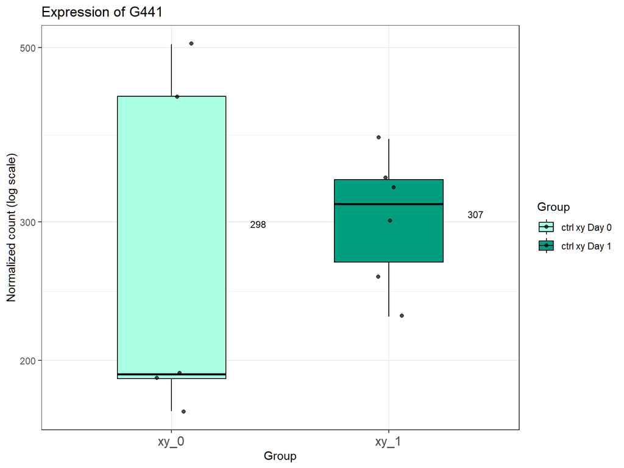

Now, the average counts are 298 (from the removal of Sample35) and 307 (same as before). From this, we would expect a LFC of about 0.04.

```r
day_xy <- results(dds_imba, contrast=list(c("Day_1_vs_0","Day1.Sexxy")), independentFiltering = FALSE)
day_xy[441,]
```

```
## log2 fold change (MLE): Day_1_vs_0+Day1.Sexxy effect
## Wald test p-value: Day_1_vs_0+Day1.Sexxy effect
## DataFrame with 1 row and 6 columns
##       baseMean log2FoldChange     lfcSE      stat    pvalue      padj
##      <numeric>      <numeric> <numeric> <numeric> <numeric> <numeric>
## G441   277.846       0.040897  0.286868  0.142564  0.886635  0.934126
```

We get the expected result using the contrast names.

Let’s try with the model matrix method.

```r
xy_0 <- colMeans(mod_mat[dds_imba$Sex == "xy" & dds_imba$Day == "0" & dds_imba$Batch == "b", ])
xy_1 <- colMeans(mod_mat[dds_imba$Sex == "xy" & dds_imba$Day == "1" & dds_imba$Batch == "b", ])

day_xy <- results(dds_imba, contrast = xy_1 - xy_0, independentFiltering = FALSE)
day_xy[441,]
```

```
## log2 fold change (MLE): 0,+1,0,+0.1,-0.166666666666667,0,+0.166666666666667,-0.166666666666667,+0.833333333333333
## Wald test p-value: 0,+1,0,+0.1,-0.166666666666667,0,+0.166666666666667,-0.166666666666667,+0.833333333333333
## DataFrame with 1 row and 6 columns
##       baseMean log2FoldChange     lfcSE      stat    pvalue      padj
##      <numeric>      <numeric> <numeric> <numeric> <numeric> <numeric>
## G441   277.846      0.0922042  0.267827  0.344268  0.730645   0.82189
```

We get a slightly different result (0.09) because the model uses ratios from the amount of samples.

This can be seen in the printed output of the values given to each column of the model matrix :

0,+1,0,+0.1,-0.166666666666667,0,+0.166666666666667,-0.166666666666667,+0.833333333333333

These values in the “contrast vector” represent the weights of each factors of the model matrix taken into account for this specific contrast

The imbalance of replicates for cultivars in some groups (when n=5, genotypes are 2 + 3) skews the group contrast (decimals values in the contrast vector).

This method is still usable, as it is quite easy to implement, but it needs to be well understood.

#### Using a Contrast Vector

**The third way to call for contrast, using a contrast vector, is more precise**

```r
# define weights for each factor
contrast_vector_day <- c(0,1,0,0,0,0,0,0,1) # this is the same vector, without decimal values from imbalance
day_xy_imba <- results(dds_imba, contrast = contrast_vector_day, independentFiltering = FALSE)
day_xy_imba[441,]
```

```
## log2 fold change (MLE): 0,+1,0,0,0,0,0,0,+1
## Wald test p-value: 0,+1,0,0,0,0,0,0,+1
## DataFrame with 1 row and 6 columns
##       baseMean log2FoldChange     lfcSE      stat    pvalue      padj
##      <numeric>      <numeric> <numeric> <numeric> <numeric> <numeric>
## G441   277.846       0.040897  0.286868  0.142564  0.886635  0.934126
```

This result shows the expected LFC value from the effect of photoperiod change on males on the imbalanced dataset, as found previously using contrast names: “list(c(”Day_1_vs_0”,“Day1.Sexxy”)).

## Using Contrast Vectors for our Experimental Design

### Effect of Treatments

First, let’s plot the female and male expressions separately, for all groups, to get a better intuition of the comparisons we are trying to extract.

The experimental design requires to use the change in expression from the photoperiod change from control samples of each sex across days, then substracting this effect to the change in expression of the treated samples. We assume no interaction between the photoperiod change and the treatment.

We can’t simply compare the treated samples at day 1 with the controls at day 1, which would be the standard way of obtaining the effect of treatment, since this would include the batch variation

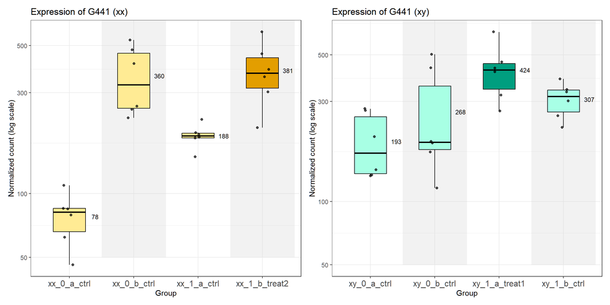

For this G441 gene, control female samples that underwent a photoperiod change between day 0 and 1 had their expression level go from 78 to 188, so we expect the effect of Day to be 1.27, as found previously. Since treated samples from batch B had this day change effect, we would expect the counts to go from 360 to about 868. However, they show nearly unchanged expression (360 to 381), with a LFC of 0.08. The effect of the treatment should then be 0.08 - 1.27, which is around -1.19.

For males, control samples had their expression level go from 268 to 307 (batch B), so we expect the effect of Day in males to be 0.20, as found previously. For treated samples, we would expect the counts to go from 193 to about 221. However, the average expression is around 424, for a LFC of 1.14. The effect of the treatment should then be 1.14 - 0.20, which is around 0.94.

Using contrast vectors, we can easily extract these contrasts. Note that treated male samples are labelled as “treat1” in colData, and females are “treat2”.

```r
cv_treat_xx <- c(0,0,0,0,0,0,1,0,0)
treat_xx <- results(dds, contrast = cv_treat_xx, independentFiltering = FALSE)
treat_xx[441,]
```

```
## log2 fold change (MLE): 0,0,0,0,0,0,+1,0,0
## Wald test p-value: 0,0,0,0,0,0,+1,0,0
## DataFrame with 1 row and 6 columns
##       baseMean log2FoldChange     lfcSE      stat     pvalue      padj
##      <numeric>      <numeric> <numeric> <numeric>  <numeric> <numeric>
## G441   274.793        -1.1824  0.407453  -2.90193 0.00370874 0.0475479
```

```r
cv_treat_xy <- c(0,0,0,0,0,1,0,0,0)
treat_xy <- results(dds, contrast = cv_treat_xy, independentFiltering = FALSE)
treat_xy[441,]
```

```
## log2 fold change (MLE): 0,0,0,0,0,+1,0,0,0
## Wald test p-value: 0,0,0,0,0,+1,0,0,0
## DataFrame with 1 row and 6 columns
##       baseMean log2FoldChange     lfcSE      stat    pvalue      padj
##      <numeric>      <numeric> <numeric> <numeric> <numeric> <numeric>
## G441   274.793       0.940357  0.403587      2.33 0.0198062  0.117197
```

## Complex Design

Now, let’s go further in the analysis by including the genotypes in the design. This will provide an opportunity to use contrast vectors in more complex ways.

**This part is under construction and will be updated shortly**

1. Sex difference at day 0;
2. Photoperiod change in both sexes;
3. Batch effect in both sexes

**This part is under construction and will be updated shortly**

Now that the various designs that allow us to extract the treatment effects accurately, both for XX and XY samples, are understood, we might want to correct for batch effects.

This is not needed for contrasts calling with DESeq2. Please refer to the main text “DESeq2-MultiBatch: Batch Correction for Multi-Factorial RNA-seq Experiments” for details.

However, for boxplots, bar graph, heatmaps, principal components analysis or other downstream analysis, batch effect correction can be of interest.

Since we need to correct for batch effects in XX and XY samples independently, a standard pipeline using known tools (limma’s removeBatchEffects or comBat-seq) might not provide the expected results.

# Ressources

https://github.com/csoneson/ExploreModelMatrix Interactive exploration of design matrices with ExploreModelMatrix Charlotte Soneson, Federico Marini, Michael I Love, Florian Geier and Michael B Stadler

ExploreModelMatrix: Interactive exploration for improved understanding of design matrices and linear models in R doi: 10.12688/f1000research.24187.2 Charlotte Soneson, Federico Marini, Michael I Love, Florian Geier and Michael B Stadler

https://github.com/tavareshugo/tutorial_DESeq2_contrasts Hugo Tavares (University of Cambridge, Bioinformatics Training Facility)

More explanations can be found on this video from the Bioinformagician channel : https://www.youtube.com/watch?v=OPt51qc5YJ8 Feel free to explore the channel, more videos relating to DESeq2 are available.

A guide to creating design matrices for gene expression experiments Charity W Law, Kathleen Zeglinski, Xueyi Dong, Monther Alhamdoosh, Gordon K Smyth, Matthew E Ritchie doi: 10.12688/f1000research.27893.1